# PAC2 Regresión Modelos y Métodos

Raul Perez Prats

2024-06-24

# Tabla de contenidos

## 1. Ejercicio 1

## 2. Ejercicio 2

## 3. Ejercicio 3

## 4. Apéndices

## Ejercicio 1

Cargamos los datos y aplicamos las tranformaciones pertinentes:

```r
library(dplyr)
data <- read.csv('ela_allBiomarkers.csv')
# Añadimos columna de supervivencia (1,0) a los 36 meses para poder hacer la regresión logística
data <- data %>% mutate(survived_36_months = ifelse(months_survived >= 36, 1, 0))
# Convertir variables categóricas a factores
data <- data %>%
  mutate(sex = as.factor(sex),
         onset = as.factor(onset))

dev_data <- data %>% filter(cohort %in% c("DevCohort"))
dev_val_data <- data %>% filter(cohort %in% c("DevCohort", "ValCohort1"))

val_1_data <- data %>% filter(cohort %in% c("ValCohort1"))
val_2_data <- data %>% filter(cohort %in% c("ValCohort2"))

head(dev_val_data)
```

```
##   patient    cohort  onset    sex age BMI_baseline ALSFRSR_baseline
## 1      p1 DevCohort spinal   male  51        32.82               33
## 2      p2 DevCohort spinal   male  75        24.80               36
## 3      p3 DevCohort spinal   male  57        23.48               45
## 4      p4 DevCohort spinal female  62        23.27               27
## 5      p5 DevCohort spinal   male  72        28.03               32
## 6      p6 DevCohort spinal   male  37        23.55               44
##   NfL_baseline CRP_baseline IL6_baseline months_survived survived_36_months
## 1           19        43.22        83.62              28                  0
## 2          194        30.90        89.22              26                  0
## 3           60        59.21        49.97              40                  1
## 4          230        12.35        53.10              27                  0
## 5           80        50.54        20.82              69                  1
## 6           78        47.42        88.91              34                  0
```

Head de ‘dev_val_data’ que nos permite observar de forma general el formato de los datos y sus variables.

### A)

```
## Número de pacientes que sobrevivieron 36 meses o más: 57
```

```
## Porcentaje de pacientes que sobrevivieron 36 meses o más: 44.53125 %
```

```
##
## Call:
## glm(formula = survived_36_months ~ age + sex + BMI_baseline +
##     onset + NfL_baseline + CRP_baseline + IL6_baseline, family = binomial(),
##     data = dev_val_data)
##
## Coefficients:
##               Estimate Std. Error z value Pr(>|z|)
## (Intercept)   0.821999   3.001162   0.274 0.784167
## age          -0.022257   0.029085  -0.765 0.444128
## sexmale       0.631887   0.676761   0.934 0.350462
## BMI_baseline  0.124895   0.080724   1.547 0.121819
## onsetspinal   2.015689   0.925678   2.178 0.029441 *
## NfL_baseline -0.012728   0.005835  -2.181 0.029163 *
## CRP_baseline -0.026650   0.015698  -1.698 0.089558 .
## IL6_baseline -0.059157   0.015776  -3.750 0.000177 ***
## ---
## Signif. codes:  0 '***' 0.001 '**' 0.01 '*' 0.05 '.' 0.1 ' ' 1
##
## (Dispersion parameter for binomial family taken to be 1)
##
##     Null deviance: 129.913  on 94  degrees of freedom
## Residual deviance:  73.733  on 87  degrees of freedom
## AIC: 89.733
##
## Number of Fisher Scoring iterations: 7
```

```
## Las variables significativas son: onsetspinal NfL_baseline IL6_baseline
```

Hay un 44.53% de pacientes que sobrevivieron durante 36 meses o más. Entrenamos un modelo multivariado de regresion logística para hacer una predicción binaria entre supervivencia >= 36 meses. Las variables con p-valor < 0.05 son aquellas estadísticamente significantes para la predicción correcta de la supervivencia. Estas variables significativas son ‘onset’, ‘NfL_baseline’ y ‘IL6-baseline’.

La distribución del estadístico Z es una distribución normal estándar.

### B)

Según las variables significativas del modelo entrenado en el apartado A), las características que tenemos que observar en un paciente para poder predecir exitosamente si sobrevivirá más de 36 meses son: el orígen de la ELA (onset) y los niveles de los biomarcadores Nf-L (NfL_baseline) y IL-6 (IL6-baseline). Según esta información, si se conoce el orígen de la ELA, y los niveles de cadenas ligeras de neurofilamentos e interleucina-6 en sangre podemos predecir exitosamente si el tiempo de supervivencia de nuestros pacientes será superior 36 meses. No obstante, antes de dar estas afirmaciones por buenas tenemos que comprobar si el ajuste y la calidad del modelo es buena. Para evaluar el modelo nos centraremos en los valores de:

-La desviación nula (Null deviance) mide el ajuste del modelo solo con la intersección, sin incluir ninguna de las variables predictoras. Es una medida de la discrepancia entre los valores observados y el modelo más simple (solo intersección). -La desviación residual (Residual deviance) mide el ajuste del modelo que incluye todas las variables predictoras. Es una medida de la discrepancia entre los valores observados y los valores predichos por el modelo completo. -El criterio de información de Akaike (AIC) es una medida de la calidad del modelo que considera tanto el ajuste como la complejidad del modelo. Penaliza la inclusión de más variables predictoras.

Cuanto menor es la AIC, mejor es el ajuste de nuestro modelo, por ahora como no tenemos ningún otro punto de referencia no podemos usar esta medida para evaluar el rendimiento del modelo ya que no tenemos ningún otro modelo de referencia con el que comparar la AIC y ver si es grande o pequeña.

En cambio, si comparamos la desviación nula con la desviación residual, rápidamente nos damos cuenta de que la desviación residual tan solo consigue reducir en un 43.4% el valor de la desviación nula. Teniendo en cuenta que la desviación nula es parecido a un algoritmo Zero Rule, que nos ayuda a observar el rendimiento de nuestro modelo en el caso más simple posible para usarlo de referencia y ver como mejoran las predicciones a medida que añadimos más parámetros, una reducción del 43% de la desviación en la desviación residual es un valor muy escaso, ya que un buen modelo con unos parámetros que se ajustaran bien al problema de clasificación binaria al que nos estamos enfrentando tendría un incremento mucho mayor entre la desviación nula y la desviación residual.

### C)

```
##
## Call:
## glm(formula = survived_36_months ~ age + sex + BMI_baseline +
##     onset + NfL_baseline + CRP_baseline, family = binomial(),
##     data = dev_val_data)
##
## Coefficients:
##               Estimate Std. Error z value Pr(>|z|)
## (Intercept)  -0.537924   2.505439  -0.215  0.83000
## age          -0.013087   0.023214  -0.564  0.57291
## sexmale      -0.020398   0.551988  -0.037  0.97052
## BMI_baseline  0.085872   0.070387   1.220  0.22247
## onsetspinal   1.649264   0.763020   2.161  0.03066 *
## NfL_baseline -0.013979   0.005093  -2.745  0.00605 **
## CRP_baseline -0.026306   0.012595  -2.089  0.03675 *
## ---
## Signif. codes:  0 '***' 0.001 '**' 0.01 '*' 0.05 '.' 0.1 ' ' 1
##
## (Dispersion parameter for binomial family taken to be 1)
##
##     Null deviance: 129.91  on 94  degrees of freedom
## Residual deviance:  94.57  on 88  degrees of freedom
## AIC: 108.57
##
## Number of Fisher Scoring iterations: 6
```

Si eliminamos la variable ‘IL6-baseline’ si que cambian las variables significativas, ya que ‘CRP_baseline’ pasa a ser una variable significativa en este modelo, mientras que en el modelo anterior no lo era. Por otro lado, las variables ‘onset’ y ‘NfL_baseline’ se mantienen significativas.

```
##              IL6_baseline CRP_baseline NfL_baseline         age BMI_baseline
## IL6_baseline   1.00000000  0.149259114   0.16618908  0.12431929 -0.047080440
## CRP_baseline   0.14925911  1.000000000   0.25411917 -0.05484647  0.004849834
## NfL_baseline   0.16618908  0.254119174   1.00000000  0.26009900 -0.017159925
## age            0.12431929 -0.054846473   0.26009900  1.00000000  0.132395747
## BMI_baseline  -0.04708044  0.004849834  -0.01715993  0.13239575  1.000000000
```

Esta sustitución de variables significativas de ‘IL6-baseline’ a ‘CRP_baseline’ puede ser debido a la colinealidad, ya que tal y como observamos en la matriz de correlaciones las variables con las que más se correlaciona ‘IL6-baseline’ son ‘CRP_baseline’ y ‘NfL_baseline’, como ‘NfL_baseline’ ya está en el modelo, cuando eliminamos ‘IL6-baseline’ la sustituye la siguiente variable no presente en el modelo anterior más correlacionada (CRP_baseline) ya que es el mejor candidato para tener efectos muy similares al modelo anterior en la predicción del la supervivencia. La AIC de este modelo es superior a la del anterior (108.57>89.733), por lo tanto este modelo presenta un peor ajuste y peor rendimiento a la hora de predecir correctamente el tiempo de supervivencia.

Test de Hipótesis:

H0: β*IL6_baseline = 0

H1: β*IL6_baseline ≠ 0

```r
# Log-verosimilitud del modelo completo
logLik(logistic_model)
```

```
## 'log Lik.' -36.86659 (df=8)
```

```r
# Log-verosimilitud del modelo reducido
logLik(logistic_model_no_IL6)
```

```
## 'log Lik.' -47.28524 (df=7)
```

```r
# Calcular el estadístico de la prueba
logLik_completo <- logLik(logistic_model)
logLik_reducido <- logLik(logistic_model_no_IL6)
LRT_statistic <- -2 * (logLik_reducido - logLik_completo)

# Grados de libertad (número de parámetros adicionales en el modelo completo)
df <- 1

# Valor p
p_value <- pchisq(LRT_statistic, df, lower.tail = FALSE)
print(p_value)
```

```
## 'log Lik.' 4.99996e-06 (df=7)
```

Para aceptar la Hipostesis alternativa (H1) y demostrar que el biomarcador ‘IL6_baseline’ aporta información significativa al modelo hemos comparado la logverosimilitud de los modelos con y sin ‘IL6_baseline’. Como el p-valor < 0.05 aceptamos H1 y por lo tanto no podemos usar el modelo reducido, ya que el modelo que incluye ‘IL6_baseline’ hace mejores predicciones y es más fiable. Estos resultados concuerdan con lo que hemos mencionado sobre las comparaciones de las AIC (108.57>89.733).

### D)

```r
# Ajustar el modelo nulo
null_model <- glm(survived_36_months ~ 1, data = dev_val_data, family = binomial())

# Log-verosimilitud del modelo nulo
logLik_null <- logLik(null_model)

# Calcular el pseudo R^2 de McFadden
pseudo_R2_McFadden <- 1 - (logLik_completo / logLik_null)

# Mostrar el resultado
print(pseudo_R2_McFadden)
```

```
## 'log Lik.' 0.4324437 (df=8)
```

Este valor indica que el modelo completo explica aproximadamente el 43.24% de la variabilidad en los datos que no está explicado por el modelo nulo (sin predictores). En otras palabras, este es el porcentaje de mejora en la log-verosimilitud del modelo completo comparado con el modelo nulo. Este valor está en un rango intermedio, sugiriendo que el modelo tiene un ajuste moderado. Como ya hemos mencionado anteriormente, teniendo en cuenta que se trata de una clasificacion binaria, el coeficiente R^2 McFadden debería de ser mucho más alto en un modelo con un buen ajuste en el que las variables explicasen de forma más robusta la variable objetivo.

### E)

```
## Confusion Matrix and Statistics
##
##           Reference
## Prediction  0  1
##          0 13  6
##          1  4 10
##
##                Accuracy : 0.697
##                  95% CI : (0.5129, 0.8441)
##     No Information Rate : 0.5152
##     P-Value [Acc > NIR] : 0.02655
##
##                   Kappa : 0.3911
##
##  Mcnemar's Test P-Value : 0.75183
##
##             Sensitivity : 0.7647
##             Specificity : 0.6250
##          Pos Pred Value : 0.6842
##          Neg Pred Value : 0.7143
##              Prevalence : 0.5152
##          Detection Rate : 0.3939
##    Detection Prevalence : 0.5758
##       Balanced Accuracy : 0.6949
##
##        'Positive' Class : 0
##
```

La prueba de McNemar sugiere que no hay un sesgo significativo en los errores de clasificación.

## Ejercicio 2

### A)

```
##
## Call:
## lm(formula = ALSFRSR_baseline ~ NfL_baseline + onset + sex +
##     age + sex:age, data = dev_val_data)
##
## Residuals:
##     Min      1Q  Median      3Q     Max
## -21.823  -2.797   1.427   4.231  10.546
##
## Coefficients:
##                Estimate Std. Error t value Pr(>|t|)
## (Intercept)   54.162439   6.658462   8.134  2.3e-12 ***
## NfL_baseline  -0.021197   0.005332  -3.975 0.000143 ***
## onsetspinal   -3.288594   1.593720  -2.063 0.041981 *
## sexmale      -12.004035   7.759339  -1.547 0.125401
## age           -0.184798   0.103764  -1.781 0.078334 .
## sexmale:age    0.219830   0.125731   1.748 0.083841 .
## ---
## Signif. codes:  0 '***' 0.001 '**' 0.01 '*' 0.05 '.' 0.1 ' ' 1
##
## Residual standard error: 6.165 on 89 degrees of freedom
## Multiple R-squared:  0.213,  Adjusted R-squared:  0.1688
## F-statistic: 4.817 on 5 and 89 DF,  p-value: 0.0006057
```

Vemos que el valor de la Adjusted R-squared es muy bajo y tan solo explica un 16.88% de la variabilidad del modelo. Como variables significativas tenemos a ‘NfL_baseline’ y ‘onset’. El p-valor del modelo indica que éste es significativo. Aunque su ajuste es pobre y sus predicciones poco fiables, debido a que un 83.12% de la variación de los datos no es explicada por el modelo.

### B)

Contrastes de hipotesis

1. H0: β1=0 H1: β1≠0
2. H0: β5=0 (para mujeres) H1: β5≠0 (para mujeres)
3. H0: β5=0 (para hombres) H1: β5≠0 (para hombres)

```r
library(car)

model_summary <- summary(linear_model)

# Obtener el valor p para NfL_baseline
p_value_NfL <- model_summary$coefficients["NfL_baseline", "Pr(>|t|)"]

# Verificar si el valor p es menor que 0.10
if (p_value_NfL < 0.10) {
  print("A) Rechazamos H0: El biomarcador Nf-L tiene un efecto significativo sobre la puntuación ALSFRSR.")
} else {
  print("A) No rechazamos H0: El biomarcador Nf-L no tiene un efecto significativo sobre la puntuación ALSFRSR.")
}
```

```
## [1] "A) Rechazamos H0: El biomarcador Nf-L tiene un efecto significativo sobre la puntuación ALSFRSR."
```

```r
# Probar la hipótesis lineal age + sex:age = 0
linear_hypothesis_result <- linearHypothesis(linear_model, "age + sexmale:age = 0")

# Obtener el valor p del contraste
p_value_combination <- linear_hypothesis_result[2, "Pr(>F)"]

# Verificar si el valor p es menor que 0.10
if (p_value_combination < 0.10) {
  print("B) Rechazamos H0: La edad tiene un efecto significativo sobre la puntuación ALSFRSR en mujeres")
} else {
  print("B) No rechazamos H0: La edad no tiene un efecto significativo sobre la puntuación ALSFRSR en mujeres")
}
```

```
## [1] "B) No rechazamos H0: La edad no tiene un efecto significativo sobre la puntuación ALSFRSR en mujeres"
```

```r
# Probar la hipótesis lineal age + sex:age = 1
linear_hypothesis_result <- linearHypothesis(linear_model, "age + sexmale:age = 1")

# Obtener el valor p del contraste
p_value_combination <- linear_hypothesis_result[2, "Pr(>F)"]

# Verificar si el valor p es menor que 0.10
if (p_value_combination < 0.10) {
  print("C) Rechazamos H0: La edad tiene un efecto significativo sobre la puntuación ALSFRSR en hombres.")
} else {
  print("C) No rechazamos H0: La edad no tiene un efecto significativo sobre la puntuación ALSFRSR en hombres.")
}
```

[output not shown]

### C)

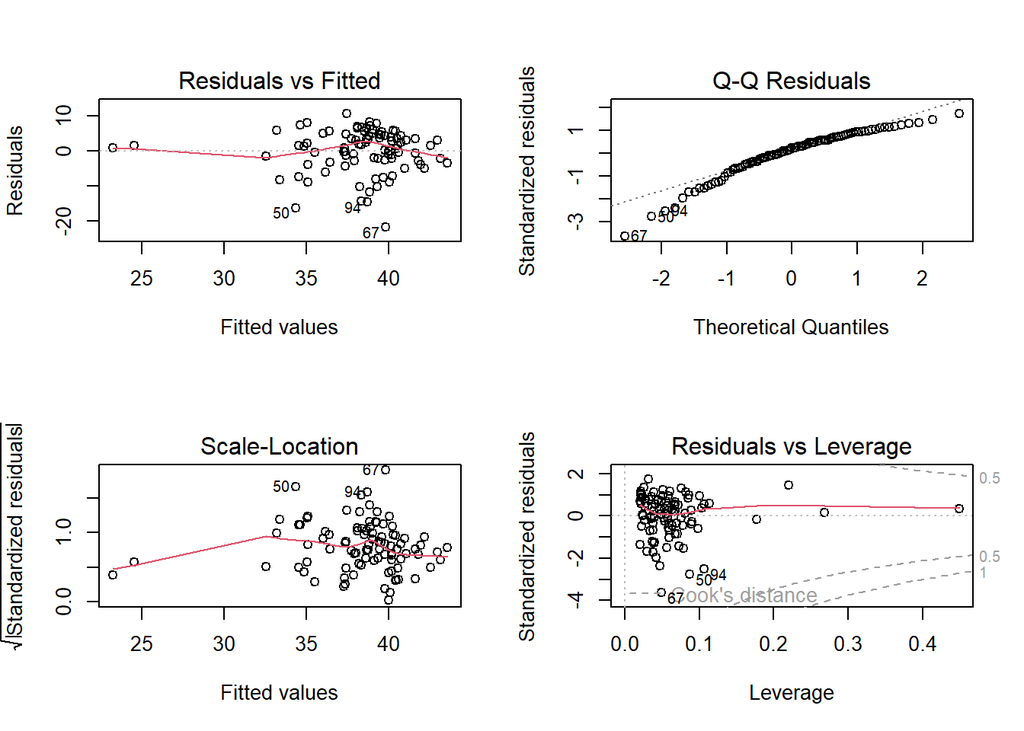

### D)

```
##
## Call: rlm(formula = ALSFRSR_baseline ~ NfL_baseline + onset + sex +
##     age + sex:age, data = dev_val_data)
## Residuals:
##      Min       1Q   Median       3Q      Max
## -22.5145  -3.2914   0.7734   3.3339   9.7615
##
## Coefficients:
##              Value   Std. Error t value
## (Intercept)  52.1003  5.9946     8.6913
## NfL_baseline -0.0212  0.0048    -4.4209
## onsetspinal  -2.4638  1.4348    -1.7172
## sexmale      -8.2510  6.9857    -1.1811
## age          -0.1511  0.0934    -1.6170
## sexmale:age   0.1618  0.1132     1.4294
##
## Residual standard error: 5.061 on 89 degrees of freedom
```

```
## Observaciones problematicas según el método Huber: 1 4 5 12 14 46 50 52 57 65 66 67 69 72 73 80 81 94
```

Estas observaciones se han clasificado como problemáticas debido a que tienen un peso < 1. Las muestras con un peso < 1 en el modelo de regresión robusta con el método Huber son aquellas que presentan una gran influencia en el modelo OLS sin ser representativas de la población, y por tanto, sesgan la regresión. La regresión robusta es capaz de corregir este sesgo disminuyendo el peso asignado a estas muestras problemàticas (a menudo outliers) y reduciendo así su influencia en el ajuste de la recta.

```
## Observaciones problematicas identificadas en el modelo OLS y el modelo de regresión robusta según el método Huber: 14 50 67 73 94
```

### E)

```
## [1] "Significancia de coeficientes para OLS:"
```

```
##  (Intercept) NfL_baseline  onsetspinal      sexmale          age  sexmale:age
##         TRUE         TRUE         TRUE        FALSE         TRUE         TRUE
```

```
## [1] "Significancia de coeficientes para modelo robusto:"
```

```
##  (Intercept) NfL_baseline  onsetspinal      sexmale          age  sexmale:age
##        FALSE         TRUE         TRUE         TRUE         TRUE        FALSE
```

Hemos observado la presencia de valores atípicos y problemas de homocedasticidad en los datos, por lo tanto, recomendamos seleccionar un modelo estadístico robusto que pueda mitigar estos efectos para disminuir el sesgo que pueden tener estos valores extremos no representativos sobre el ajuste de nuestro modelo lineal. Este enfoque es crucial para obtener estimaciones de coeficientes más fiables y precisas, particularmente en situaciones como la nuestra, donde la suposición de normalidad y homocedasticidad puede verse comprometida.

## Ejercicio 3

### A)

```
##
## Call:
## lm(formula = ALSFRSR_baseline ~ age + sex + BMI_baseline + onset +
##     NfL_baseline + CRP_baseline + IL6_baseline, data = dev_val_data)
##
## Residuals:
##     Min      1Q  Median      3Q     Max
## -20.294  -2.855   1.073   4.417  11.245
##
## Coefficients:
##               Estimate Std. Error t value Pr(>|t|)
## (Intercept)  42.917595   6.315392   6.796 1.28e-09 ***
## age          -0.041321   0.062102  -0.665 0.507571
## sexmale       1.065289   1.378124   0.773 0.441618
## BMI_baseline  0.029736   0.176779   0.168 0.866807
## onsetspinal  -2.660359   1.639318  -1.623 0.108241
## NfL_baseline -0.022505   0.005746  -3.917 0.000178 ***
## CRP_baseline  0.002413   0.023964   0.101 0.920010
## IL6_baseline  0.032422   0.027928   1.161 0.248851
## ---
## Signif. codes:  0 '***' 0.001 '**' 0.01 '*' 0.05 '.' 0.1 ' ' 1
##
## Residual standard error: 6.289 on 87 degrees of freedom
## Multiple R-squared:  0.1995, Adjusted R-squared:  0.1351
## F-statistic: 3.098 on 7 and 87 DF,  p-value: 0.005783
```

‘NfL_baseline’ es la única variable significativa del modelo. Basado en el coeficiente de determinación R^2 ajustado de 0.1351, el modelo explica aproximadamente el 13.5% de la variabilidad en la variable respuesta ALSFRSR_baseline. Esto sugiere que el modelo tiene una capacidad de ajuste moderada, indicando un ajuste pobre de la regresión a los datos.

### B)

Para comprobar la posible multicolinealidad entre las variables regresoras en un modelo de regresión lineal, podemos utilizar varios enfoques. Uno de los métodos más comunes es calcular el Factor de Inflación de la Varianza (Variance Inflation Factor o VIF) para cada variable independiente. El VIF indica cuánto aumenta la varianza de un coeficiente estimado debido a la multicolinealidad con otras variables en el modelo. Generalmente, se considera que un VIF mayor que 10 indica multicolinealidad problemática.

```r
# Calcular VIF para cada variable regresora
vif_values <- vif(lineal_model_2)
print(vif_values)
```

```
##          age          sex BMI_baseline        onset NfL_baseline CRP_baseline
##     1.062029     1.073775     1.008370     1.218929     1.371576     1.173195
## IL6_baseline
##     1.117081
```

Los resultados del cálculo del VIF para cada variable regresora indican que todos los valores están por debajo de 5, lo cual sugiere que no hay problemas significativos de multicolinealidad entre las variables en el modelo. Por lo tanto, podemos concluir que las variables regresoras están razonablemente independientes entre sí en términos de multicolinealidad, lo cual es favorable para la precisión de las estimaciones y las inferencias del modelo de regresión lineal.

### C)

```
##
## Call:
## lm(formula = ALSFRSR_baseline ~ onset + NfL_baseline, data = dev_val_data)
##
## Residuals:
##     Min      1Q  Median      3Q     Max
## -21.012  -2.747   1.388   4.372   9.703
##
## Coefficients:
##               Estimate Std. Error t value Pr(>|t|)
## (Intercept)  43.741878   1.735330  25.207  < 2e-16 ***
## onsetspinal  -2.908101   1.589404  -1.830   0.0705 .
## NfL_baseline -0.023061   0.005252  -4.391 3.01e-05 ***
## ---
## Signif. codes:  0 '***' 0.001 '**' 0.01 '*' 0.05 '.' 0.1 ' ' 1
##
## Residual standard error: 6.214 on 92 degrees of freedom
## Multiple R-squared:  0.1734, Adjusted R-squared:  0.1555
## F-statistic: 9.653 on 2 and 92 DF,  p-value: 0.0001565
```

Los resultados del stepwise regression concuerdan con los resultados del modelo anterior en el que se indicaba que ‘NfL_baseline’ es la úncia variable significativa, ya que en el stepwise regression únicamente se han seleccionado las variables ‘NfL_baseline’ y ‘onset’, las demás variables han sido descartadas. Además, utilizando tan solo estas 2 variables obtenemos un valor más alto para la R^2 ajustada (0.1555>0.1351), por lo tanto, este modelo con menos variables tiene un mejor ajuste a los datos que el modelo que usa todas las variables regresoras para las predicciones.

Esto indica que las variables que han sido descartadas no aportan capacidad predictiva al modelo.

### D)

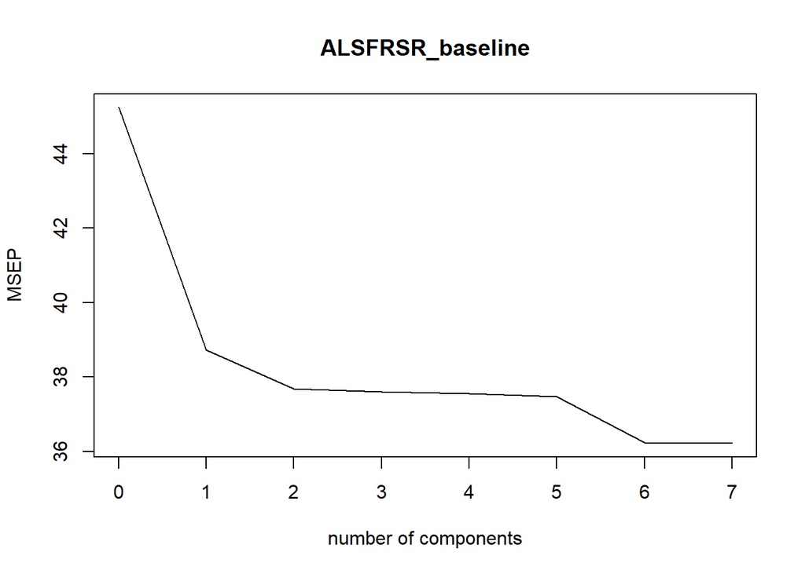

El número más razonable de componentes corresponde a 2, donde se encuentra el ‘codo’ del gráfico.

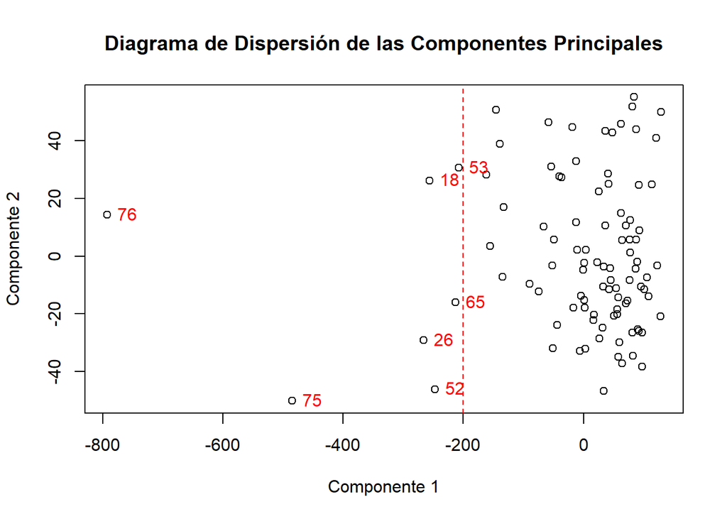

Observamos como el grueso de los valores se distribuye en la componente 1 alrededor del valor 0, existen 7 outliers que se extienden en el eje horizontal entre los valores -200 y -800. Estos puntos son: 53, 65, 52, 26, 75, 18 y 76

Respecto al componente 2 los puntos parecen distribuirse bastante uniformemente a lo largo de todo el eje vertical, por lo tanto es complicado establecer agrupaciones y detectar outliers.

### E)

```
## Lambda mínimo: 0.2730886
```

```
## 5 x 1 sparse Matrix of class "dgCMatrix"
##                       s1
## (Intercept)  39.43989871
## BMI_baseline  .
## IL6_baseline  0.02983295
## NfL_baseline -0.01809628
## CRP_baseline  .
```

### F)

```
## [1] "RMSE para LASSO dev_val_data: 6.72621283176289"
```

```
## [1] "RMSE para PLS dev_val_data: 5.36324231587816"
```

```
## [1] "RMSE para LASSO ValCohort2: 4.94885391183775"
```

```
## [1] "RMSE para PLS ValCohort2: 4.77999306434593"
```

El modelo PLS con 2 componentes muestra consistentemente un mejor rendimiento predictivo tanto en dev_val_data como en ValCohort2, basado en los valores más bajos de RMSE en ambos conjuntos de datos.

## 4. Apéndices

Ejercicio 1 A)

```r
# Mostrar el número de pacientes que sobrevivieron 36 meses o más
num_survived_36_months <- nrow(data %>% filter(months_survived >= 36))
cat("Número de pacientes que sobrevivieron 36 meses o más:", num_survived_36_months, "\n")

# Calcular el porcentaje de supervivencia a los 36 meses
total_patients <- nrow(data)
surv_percentage_36_months <- (num_survived_36_months / total_patients) * 100

cat("Porcentaje de pacientes que sobrevivieron 36 meses o más:", surv_percentage_36_months, "%\n")

#-------------------------------------------------------------------------------------------------------------------------



# Ajustar el modelo de regresión logística
logistic_model <- glm(survived_36_months ~ age + sex + BMI_baseline + onset + NfL_baseline + CRP_baseline + IL6_baseline,
                      data = dev_val_data,
                      family = binomial())

# Resumen del modelo
summary(logistic_model)

# Identificar las variables significativas
significant_vars <- summary(logistic_model)$coefficients[,4] < 0.05
significant_vars <- names(significant_vars[significant_vars])
cat("Las variables significativas son:", significant_vars, "\n")
```

Ejercicio 1 C)

```r
# Ajustar el modelo de regresión logística
logistic_model_no_IL6 <- glm(survived_36_months ~ age + sex + BMI_baseline + onset + NfL_baseline + CRP_baseline,# + IL6_baseline,
                      data = dev_val_data,
                      family = binomial())

# Resumen del modelo
summary(logistic_model_no_IL6)

# Calculamos matriz de correlaciones
cor(data[, c("IL6_baseline", "CRP_baseline", "NfL_baseline", "age", "BMI_baseline")])
```

Ejercicio 1 E)

```r
library(caret)

#val_2_data
# Predicciones de probabilidades
predicted_probabilities <- predict(logistic_model, newdata = val_2_data, type = "response")

# Convertir probabilidades en clases
predicted_classes <- ifelse(predicted_probabilities > 0.5, 1, 0)

# Crear la matriz de confusión
conf_matrix <- confusionMatrix(as.factor(predicted_classes), as.factor(val_2_data$survived_36_months))

# Mostrar la matriz de confusión
print(conf_matrix)
```

Ejercicio 2 A)

```r
library(tidyverse)

# Ajustar el modelo de regresión lineal
linear_model <- lm(ALSFRSR_baseline ~ NfL_baseline + onset + sex + age + sex:age, data = dev_val_data)

# Resumen del modelo
summary(linear_model)
```

Ejercicio 2 C)

```r
# Gráficos de diagnóstico del modelo
par(mfrow = c(2, 2))
plot(model)
```

Ejercicio 2 D)

```r
library(MASS)

# Ajustar el modelo de regresión robusta usando el método Huber
robust_model <- rlm(ALSFRSR_baseline ~ NfL_baseline + onset + sex + age + sex:age, data = dev_val_data)

# Resumen del modelo robusto
summary(robust_model)

hweights <- data.frame(state = dev_val_data$ALSFRSR_baseline, resid = robust_model$resid, weight = robust_model$w)
# filtramos aquellas ponderaciones bajas porque son las que han sido corregidas por el modelo robusto y asignadas un menor weight para disminuir su influencia debido a que son problematicas o outliers.
problematic_obs_robust <- which(hweights$weight < 1)

# Imprimir las observaciones problemáticas
cat('Observaciones problematicas según el método Huber:',problematic_obs_robust)


# Identificar observaciones problemáticas en el modelo OLS
# Utilizando la distancia de Cook como referencia
cooks_distance <- cooks.distance(model)
threshold_cooks <- 4 / (nrow(dev_val_data) - length(coef(linear_model)))
problematic_obs_OLS <- which(cooks_distance > threshold_cooks)

# Comparar las observaciones problemáticas entre el modelo OLS y el modelo robusto
common_problematic_obs <- intersect(problematic_obs_robust, problematic_obs_OLS)

# Imprimir las observaciones problemáticas comunes
cat('Observaciones problematicas identificadas en el modelo OLS y el modelo de regresión robusta según el método Huber:',common_problematic_obs)
```

Ejercicio 2 E)

```r
# Obtener los coeficientes y p-valores del modelo OLS
ols_coef <- coef(summary(linear_model))[, "Estimate"]
ols_pvalues <- coef(summary(linear_model))[, "Pr(>|t|)"]

# Obtener los coeficientes y p-valores del modelo robusto
robust_coef <- coef(robust_model)
robust_summary <- summary(robust_model)
robust_pvalues <- robust_summary$coefficients[, "t value"]

# Comparar la significancia de los coeficientes
significancia_ols <- ols_pvalues < 0.1
significancia_robust <- robust_pvalues < 0.1

# Mostrar los resultados
print("Significancia de coeficientes para OLS:")
print(significancia_ols)

print("Significancia de coeficientes para modelo robusto:")
print(significancia_robust)
```

Ejercicio 3 A)

```r
# Ajustar el modelo de regresión lineal
lineal_model_2 <- lm(ALSFRSR_baseline ~ age + sex + BMI_baseline + onset + NfL_baseline + CRP_baseline + IL6_baseline,
                      data = dev_val_data,
                      )
summary(lineal_model_2)
```

Ejercicio 3 C)

```r
# Ajustar el modelo inicial
lineal_model_3 <- lm(ALSFRSR_baseline ~ age + sex + BMI_baseline + onset +
                     NfL_baseline + CRP_baseline + IL6_baseline, data = dev_val_data)

# Aplicar el método paso a paso con criterio AIC
modelo_seleccionado <- step(lineal_model_3, direction = "both", trace = 0)

# Mostrar el resumen del modelo seleccionado
summary(modelo_seleccionado)
```

Ejercicio 3 D)

```r
library(pls)

# Ajustar el modelo PLS
modelo_pls <- plsr(ALSFRSR_baseline ~ age + sex + BMI_baseline + onset +
                   NfL_baseline + CRP_baseline + IL6_baseline, ncomp = 7, data = dev_val_data)
# Determinar el número óptimo de componentes basado en RMSE
validationplot(modelo_pls, val.type = "MSEP")
```

```r
# Obtener las componentes principales del modelo PLS
scores <- predict(modelo_pls, type = "scores")

# Crear un gráfico de dispersión de las componentes principales
plot(scores[, 1], scores[, 2], main = "Diagrama de Dispersión de las Componentes Principales",
     xlab = "Componente 1", ylab = "Componente 2")

# Agregar línea de referencia en la componente 1
abline(v = -200, col = "red", lty = 2)

# Etiquetar los puntos que están por debajo de -200 en la componente 1
points_below <- which(scores[, 1] < -200)
text(scores[points_below, 1], scores[points_below, 2], labels = points_below, pos = 4, col = "red")
```

Ejercicio 3 E)

```r
library(glmnet)

# Definir las variables predictoras y la variable de respuesta
predictors <- c("BMI_baseline", "IL6_baseline", "NfL_baseline", "CRP_baseline")
response <- "ALSFRSR_baseline"

# Crear el conjunto de datos con las variables seleccionadas
datos <- dev_val_data[, c(predictors, response)]

# Separar las variables predictoras y la variable de respuesta
X <- as.matrix(datos[, predictors])
y <- datos[, response]

# Ajustar el modelo LASSO con cv.glmnet para seleccionar el lambda óptimo
lasso_model <- cv.glmnet(X, y, alpha = 1)  # alpha = 1 para regresión LASSO

# Obtener el valor de lambda mínimo
lambda_min <- lasso_model$lambda.min
cat('Lambda mínimo:',lambda_min)

# Obtener la fórmula del modelo con el lambda mínimo
coeficientes <- coef(lasso_model, s = "lambda.min")
print(coeficientes)
```

Ejercicio 3 F)

```r
# Seleccionar solo las variables usadas en el modelo LASSO
newx_lasso <- as.matrix(dev_val_data[, c("BMI_baseline", "IL6_baseline", "NfL_baseline", "CRP_baseline")])

# Realizar las predicciones y calcular el RMSE
predicciones_lasso_n <- predict(lasso_model, newx = newx_lasso)
rmse_lasso_n <- sqrt(mean((dev_val_data$ALSFRSR_baseline - predicciones_lasso_n)^2))

predicciones_pls_n <- predict(modelo_pls, newdata = dev_val_data, ncomp = 2)
rmse_pls_n <- sqrt(mean((val_2_data$ALSFRSR_baseline - predicciones_pls_n)^2))

# Mostrar los resultados de RMSE
print(paste("RMSE para LASSO dev_val_data:", rmse_lasso_n))
print(paste("RMSE para PLS dev_val_data:", rmse_pls_n))

#-------------------------------------------------------------------------------------------------------------------------------------

# Seleccionar solo las variables usadas en el modelo LASSO
newx_lasso_n <- as.matrix(val_2_data[, c("BMI_baseline", "IL6_baseline", "NfL_baseline", "CRP_baseline")])

# Realizar las predicciones y calcular el RMSE
predicciones_lasso_n <- predict(lasso_model, newx = newx_lasso_n)
rmse_lasso_n <- sqrt(mean((val_2_data$ALSFRSR_baseline - predicciones_lasso_n)^2))

predicciones_pls_n <- predict(modelo_pls, newdata = val_2_data, ncomp = 2)
rmse_pls_n <- sqrt(mean((val_2_data$ALSFRSR_baseline - predicciones_pls_n)^2))

# Mostrar los resultados de RMSE
print(paste("RMSE para LASSO ValCohort2:", rmse_lasso_n))
print(paste("RMSE para PLS ValCohort2:", rmse_pls_n))
```